# efe

```python
import numpy as np
import matplotlib.pyplot as plt
def stdnorm(X):
    """
    Inputs:
    - X: A numpy array of shape (N, D)
    Returns:
    A numpy array of shape (N, D) where Y[i] contains the same data as X[i],
    but normalized to have zero mean and unit standard deviation.
    Hint: Use the axis argument for calculations along the correct axis.
    Use the keepdims argument to be able to do broadcasting.
    """

    # FILL HERE: one-line long code only, for part (b)
    return  (X-np.mean(X, axis=0, keepdims=True))/np.std(X, axis=0, keepdims=True)
N = 10
D = 3
# x_org = np.arange(1, N+1).reshape(N,1) @ np.arange(1, D+1).reshape(1,D)
x_org = np.arange(1, N+1)[:, np.newaxis] * np.arange(1, D+1)
print(x_org.shape)
print(x_org)
x_norm = stdnorm(x_org)
print(x_norm)
print('Mean:', np.mean(x_norm, axis=0))
print('Std:', np.std(x_norm, axis=0))
```

```
(10, 3)
[[ 1  2  3]
 [ 2  4  6]
 [ 3  6  9]
 [ 4  8 12]
 [ 5 10 15]
 [ 6 12 18]
 [ 7 14 21]
 [ 8 16 24]
 [ 9 18 27]
 [10 20 30]]
[[-1.5666989  -1.5666989  -1.5666989 ]
 [-1.21854359 -1.21854359 -1.21854359]
 [-0.87038828 -0.87038828 -0.87038828]
 [-0.52223297 -0.52223297 -0.52223297]
 [-0.17407766 -0.17407766 -0.17407766]
 [ 0.17407766  0.17407766  0.17407766]
 [ 0.52223297  0.52223297  0.52223297]
 [ 0.87038828  0.87038828  0.87038828]
 [ 1.21854359  1.21854359  1.21854359]
 [ 1.5666989   1.5666989   1.5666989 ]]
Mean: [-1.11022302e-16 -1.11022302e-16 -1.11022302e-16]
Std: [1. 1. 1.]
```

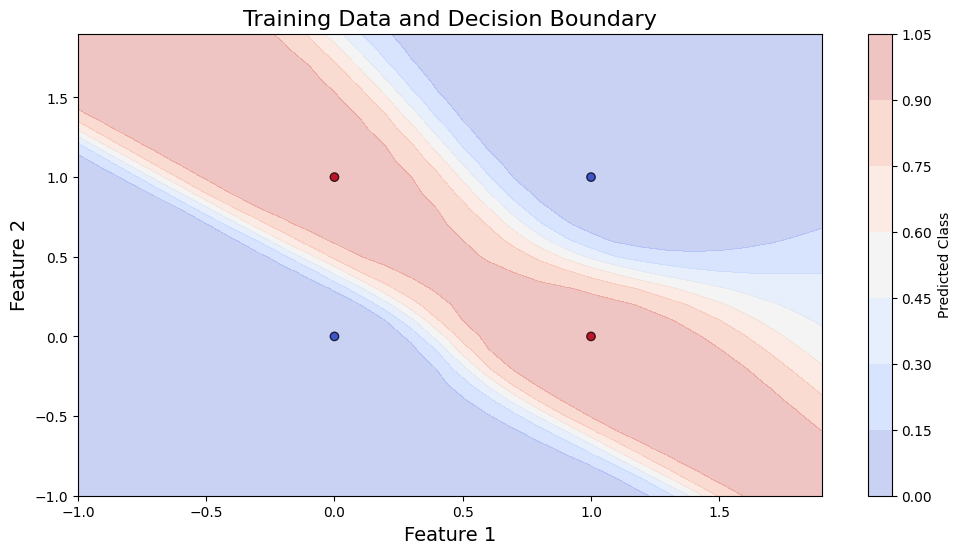

```python
import numpy as np
import matplotlib.pyplot as plt
import random

def sigmoid(X):
    return 1/(1+np.exp(-X))

def sigmoid_deriv(X):
    return sigmoid(X)*(1-sigmoid(X))

def forward(X,W1,W2,predict=False):
    a1=np.matmul(X,W1) #matrix çarpımı yaptım
    Z1=sigmoid(a1)

    bias=np.ones((len(Z1),1))
    Z1=np.concatenate((bias,Z1),axis=1)  #biası z1 in bir parçası gibi düşünüp formülden çıkardım
    a2=np.matmul(Z1,W2)
    Z2=sigmoid(a2)
    if predict:
        return Z2
    return a1,Z1,a2,Z2

def backward_prop(a2,z0,z1,z2,y):
    d2=z2-y
    D2=np.matmul(z1.T,d2)
    d1=(d2.dot(W2[1:,:].T))*sigmoid_deriv(a1)
    D1=np.matmul(z0.T,d1)
    return d2,D1,D2

X=np.array([[1,1,0]
            ,[1,0,1]
            ,[1,0,0]
            ,[1,1,1]])

Y=np.array([[1],[1],[0],[0]])

W1=np.random.rand(3,5)
W2=np.random.rand(6,1)

lr=0.09
loses=[]

epochs=10000
m=len(X)
for i in range(epochs):

    #forward
    a1,z1,a2,z2=forward(X,W1,W2)

    #backwarodprop
    d2,D1,D2 = backward_prop(a2,X,z1,z2,Y)

    W1-=lr*(1/m)*D1
    W2-=lr*(1/m)*D2

    c=np.mean(np.abs(d2))
    loses.append(c)




plt.figure(figsize=(12, 6))

# Plot training data points
plt.scatter(X[:, 1], X[:, 2], c=Y.flatten(), cmap=plt.cm.coolwarm, edgecolors='k')
plt.xlabel('Feature 1', fontsize=14)
plt.ylabel('Feature 2', fontsize=14)
plt.title('Training Data and Decision Boundary', fontsize=16)

# Generate a grid of points to plot decision boundary
x_min, x_max = X[:, 1].min() - 1, X[:, 1].max() + 1
y_min, y_max = X[:, 2].min() - 1, X[:, 2].max() + 1
xx, yy = np.meshgrid(np.arange(x_min, x_max, 0.1),
                     np.arange(y_min, y_max, 0.1))

# Flatten the grid and perform forward propagation to get predictions
grid = np.c_[np.ones((len(xx.ravel()), 1)), xx.ravel(), yy.ravel()]
Z = forward(grid, W1, W2, predict=True)
Z = Z.reshape(xx.shape)

# Plot decision boundary
plt.contourf(xx, yy, Z, alpha=0.3, cmap=plt.cm.coolwarm)

plt.colorbar(label='Predicted Class')
plt.xlim(xx.min(), xx.max())
plt.ylim(yy.min(), yy.max())

plt.show()
```

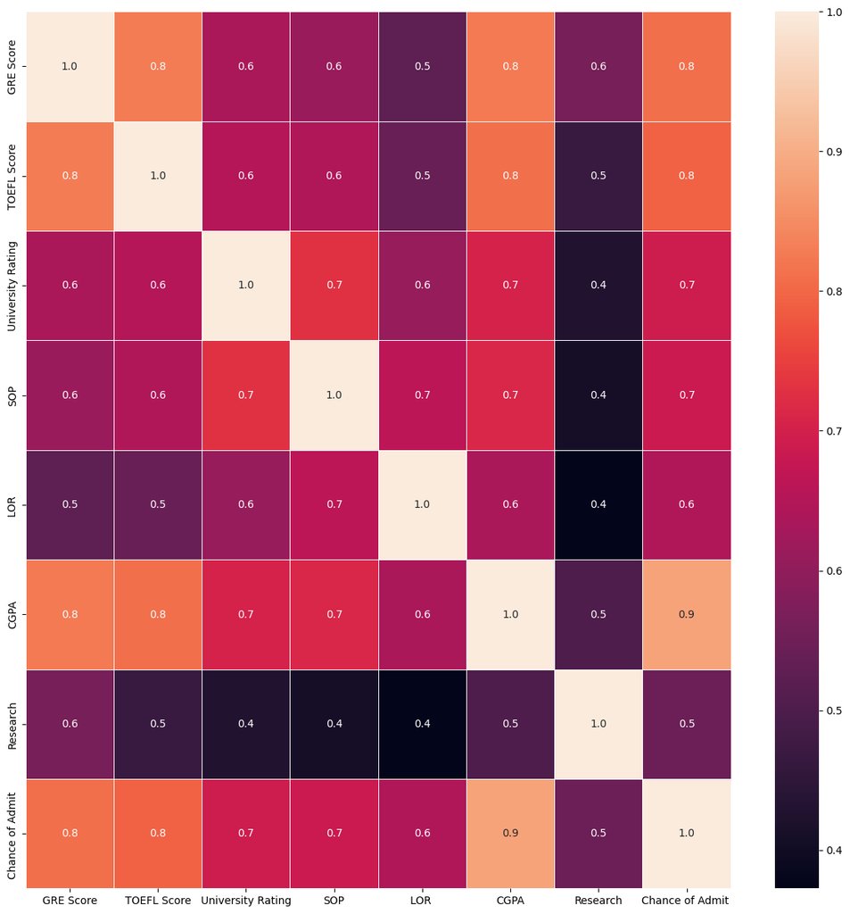

```python
import pandas as pd
import matplotlib.pyplot as plt
import seaborn as sns
# Read the dataset
dataset = pd.read_csv('admissionv2.csv')
# Explore the dataset
# Observe that the scales and centers are very different which needs to be fixed,
# and the column "Serial No." is actually just the row number so it must be removed.
dataset # To print the dataset (In a jupyter notebook there is no need to use the print command)
dataset.head(10) # Or, you can print only the first 10 lines
dataset.describe() # The basic statistical description of the dataset
# Remove the useless "Serial No."
dataset.drop('Serial No.', axis=1, inplace=True)
# Let's look at the correlations across the columns.
dataset.corr() # Print the correlations
# We can see easier when we draw a correlation heatmap
f,ax = plt.subplots(figsize=(15, 15))
sns.heatmap(dataset.corr(), annot=True, linewidths=0.5, linecolor="white", fmt= '.1f',ax=ax)
plt.show()
# Which score looks like the most related to the admission chance?
```

```python
# Let's prepare the dataset for the experimentation
import numpy as np
from sklearn.model_selection import train_test_split
from sklearn.preprocessing import StandardScaler
from sklearn.metrics import r2_score, root_mean_squared_error
# Separate the targets from the inputs
X = dataset.iloc[:,:-1].values
Y = dataset.iloc[:,7].values.reshape(-1,1) # Chance of admission
# Convert to numpy arrays
X = np.array(X)
Y = np.array(Y)
# Split the training and validation sets (ensuring the same split always)
x_train, x_valid, y_train, y_valid = train_test_split(X, Y, test_size=0.30,
shuffle=False, random_state=1)
# Preprocessing (by standard normalization since we observed quite different scales/centers)
scaler = StandardScaler()
x_train = scaler.fit_transform(x_train) # We fit the scaler only on the training set
x_valid = scaler.transform(x_valid) # We use the resulting fit on the validation set
print(x_train.shape, x_valid.shape)
```

```
(350, 7) (150, 7)
```

```python
# Implementing the Logistic Regression
class TwoLayerMLP:
    def __init__(self, input_size, hidden_size, output_size,batch_size, reg_lambda,rho=0.9,learning_rate=0.01):
        self.input_size = input_size
        self.hidden_size = hidden_size
        self.output_size = output_size
        self.reg_lambda = reg_lambda
        self.rho=rho
        self.batch_size=batch_size
        self.init_weights()
        self.zero_grad()
        self.learning_rate = learning_rate

    def init_weights(self):
        self.W1 = np.random.randn(self.input_size, self.hidden_size) * 0.01
        self.b1 = np.zeros((1, self.hidden_size))
        self.W2 = np.random.randn(self.hidden_size, self.output_size) * 0.01
        self.b2 = np.zeros((1, self.output_size))
        self.velocity_W1 = np.zeros_like(self.W1)
        self.velocity_b1 = np.zeros_like(self.b1)
        self.velocity_W2 = np.zeros_like(self.W2)
        self.velocity_b2 = np.zeros_like(self.b2)


    def zero_grad(self):
        self.dW1 = np.zeros_like(self.W1)
        self.db1 = np.zeros_like(self.b1)
        self.dW2 = np.zeros_like(self.W2)
        self.db2 = np.zeros_like(self.b2)


    def update_weights(self, learning_rate):
           # Update velocity terms
        self.velocity_W1 = self.rho * self.velocity_W1 + self.dW1
        self.velocity_b1 = self.rho * self.velocity_b1 + self.db1
        self.velocity_W2 = self.rho * self.velocity_W2 + self.dW2
        self.velocity_b2 = self.rho * self.velocity_b2 + self.db2

        # Update parameters
        self.W1 -= learning_rate * self.velocity_W1
        self.b1 -= learning_rate * self.velocity_b1
        self.W2 -= learning_rate * self.velocity_W2
        self.b2 -= learning_rate * self.velocity_b2



    def sigmoid(self, Z):
        return 1 / (1 + np.exp(-Z))

    def sigmoid_derivative(self, Z):
        s = self.sigmoid(Z)
        return s * (1 - s)

    def forward(self, X, Y=None):
        self.X = X
        if Y is not None:
            self.Y = Y


        self.Z1=self.sigmoid(np.dot(X,self.W1)+self.b1)
        self.H1=self.Z1
        self.Z2=self.sigmoid(np.dot(self.Z1,self.W2)+self.b2)
        self.H2=self.Z2

        return self.H2

    def compute_loss(self, Y_pred=None, Y=None):
        if Y_pred is None:
            Y_pred = self.H2
        if Y is None:
            Y = self.Y


        batch_size = Y.shape[0]
        data_loss = np.sum((Y_pred - Y) ** 2) / batch_size
        reg_loss = (self.reg_lambda / 2) *np.sum(np.square(self.W1)+np.sum(np.square(self.W2))) / batch_size
        loss = data_loss + reg_loss
        return loss


    def backward(self,X,Y):
        Y_pred = self.H2
        batch_size = Y.shape[0]

        dZ2 = (Y_pred - Y) * self.sigmoid_derivative(self.Z2)
        self.dW2 = (np.dot(self.H1.T, dZ2) + self.reg_lambda * self.W2) / batch_size
        self.db2 = np.sum(dZ2, axis=0, keepdims=True) / batch_size
        #dZ1 = np.dot(dZ2[:, :self.hidden_size], self.W2.T) * self.sigmoid_derivative(self.Z1)
        dZ1 = np.dot(dZ2, self.W2.T) * self.sigmoid_derivative(self.Z1)
        self.dW1 = (np.dot(X.T, dZ1) + self.reg_lambda * self.W1) / batch_size
        self.db1 = np.sum(dZ1, axis=0, keepdims=True) / batch_size

    def predict(self, X):
        # Predict output for new data
        return self.forward(X)
    def train(self, X, y, epochs=1000):
        for i in range(epochs):
            # Forward propagation
            self.forward(X)

            # Backpropagation
            self.backward(X, y)
            self.update_weights(self.learning_rate)
```

```python
class SGD:
    def __init__(self, model, learning_rate):
        self.model = model
        self.learning_rate = learning_rate

    def step(self):
        self.model.update_weights(self.learning_rate)

    def zero_grad(self):
        self.model.zero_grad()

def train_sgd(model, optimizer, X_train, Y_train, epochs, batch_size):
    loss_list = []
    n_samples = X_train.shape[0]

    for epoch in range(epochs):
        total_loss = 0
        indices = np.random.permutation(n_samples)

        for i in range(0, n_samples, batch_size):
            batch_indices = indices[i:i+batch_size]
            X_batch = X_train[batch_indices]
            Y_batch = Y_train[batch_indices]

            model.forward(X_batch, Y_batch)
            loss = model.compute_loss()
            model.backward(X_batch, Y_batch)
            optimizer.step()
            optimizer.zero_grad()
            total_loss += loss

        avg_loss = total_loss / (n_samples / batch_size)
        loss_list.append(avg_loss)

    return loss_list
```

### R2 (Coefficient of Determination)

The coefficient of determination, denoted as R2, is a statistical measure that represents the proportion of the variance for a dependent variable that's explained by an independent variable(s) in a regression model. It is calculated as:

R^2 = 1 - \frac{SS_{res}}{SS_{tot}}

Where:

- ( SS_{res} ) is the sum of squares of residuals (or errors)
- ( SS_{tot} ) is the total sum of squares

R2 ranges from 0 to 1, where:

- 0 indicates that the model does not explain any of the variance in the target variable.
- 1 indicates that the model explains all the variance in the target variable.

### RMSE (Root Mean Square Error)

The root mean square error, denoted as RMSE, measures the average magnitude of the errors between predicted and actual values in a regression problem. It is calculated as the square root of the average of squared differences between predicted and actual values:

[ RMSE = \sqrt{\frac{1}{n}\sum_{i=1}^{n}(y_{i} - \hat{y}_{i})^2} ]

Where:

- ( n ) is the number of data points
- ( y_{i} ) is the actual value
- ( \hat{y}_{i} ) is the predicted value

RMSE can range from 0 to positive infinity. Lower RMSE values indicate better model performance, where an RMSE of 0 would denote a perfect prediction.

### Range and Interpretation

- **R2 Range:** 0 to 1
- **RMSE Range:** 0 to positive infinity
- **Perfect Prediction:**
  - R2: 1
  - RMSE: 0

  **Reasoning:**
  - A perfect R2 score of 1 means that the model explains all the variability of the response data around its mean.
  - A RMSE of 0 indicates that the predicted values perfectly match the observed values, meaning there are no errors.
- **Terrible Prediction:**
  - R2: Close to 0
  - RMSE: High value (much greater than 0)

  **Reasoning:**
  - A low R2 score close to 0 suggests that the model does not explain much of the variability in the response data.
  - A high RMSE value indicates large discrepancies between predicted and actual values, implying poor model performance.

```
Best hyperparameters: hidden_size=20, reg_lambda=0.01, learning_rate=1, batch_size=32
Best R2: 0.8519059149018459
Best RMSE: 0.05495570406534662
```

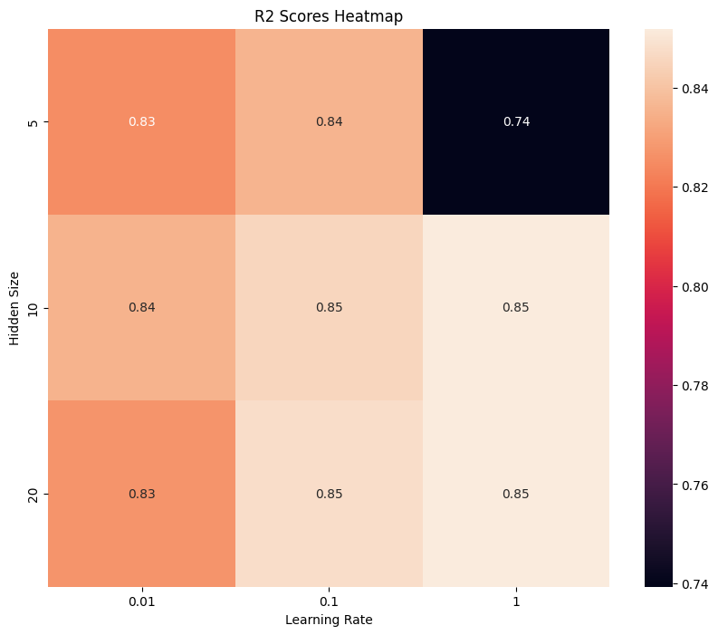

```python
import seaborn as sns

# Initialize lists to store hyperparameters and corresponding scores
hidden_sizes = [5,10,20]
reg_lambdas = [0.01, 0.1, 1]
learning_rates = [0.01, 0.1, 1]
batch_sizes = [32, 64,128]

r2_scores = np.zeros((len(hidden_sizes), len(learning_rates)))
rmse_scores = np.zeros((len(hidden_sizes), len(learning_rates)))

best_r2 = -np.inf
best_rmse = np.inf
best_params = None

# Hyperparameter tuning with grid search
for i, hidden_size in enumerate(hidden_sizes):
    for j, learning_rate in enumerate(learning_rates):
        for reg_lambda in reg_lambdas:
            for batch_size in batch_sizes:
                model = TwoLayerMLP(input_size=x_train.shape[1], hidden_size=hidden_size, output_size= y_valid.shape[1],batch_size=batch_size, reg_lambda=reg_lambda)
                optimizer = SGD(model, learning_rate=learning_rate)
                loss_list = train_sgd(model, optimizer, x_train, y_train, epochs=1000, batch_size=batch_size)
                y_pred = model.predict(x_valid)
                r2 = r2_score(y_valid, y_pred)
                rmse = root_mean_squared_error(y_valid, y_pred)
                #print(f'hidden_size={hidden_size}, reg_lambda={reg_lambda}, learning_rate={learning_rate}, batch_size={batch_size}, R^2={r2}, RMSE={rmse}')

                # Update best scores and parameters
                if r2 > best_r2:
                    best_r2 = r2
                    best_rmse = rmse
                    best_params = (hidden_size, reg_lambda, learning_rate, batch_size)

                # Update scores for heatmap
                if reg_lambda == best_params[1] and batch_size == best_params[3]:
                    r2_scores[i, j] = r2
                    rmse_scores[i, j] = rmse

print(f'Best hyperparameters: hidden_size={best_params[0]}, reg_lambda={best_params[1]}, learning_rate={best_params[2]}, batch_size={best_params[3]}')
print(f'Best R2: {best_r2}')
print(f'Best RMSE: {best_rmse}')

# Plot heatmap
plt.figure(figsize=(10, 8))
sns.heatmap(r2_scores, annot=True, xticklabels=learning_rates, yticklabels=hidden_sizes)
plt.xlabel('Learning Rate')
plt.ylabel('Hidden Size')
plt.title('R2 Scores Heatmap')
plt.show()
```

References:

- ChatGPT
- https://www.youtube.com/@MichiganOnline
- https://www.youtube.com/@simpledeeplearning4705
- My Classmates
- Our Lab Codes